# 基于持仓数据整体股票型基金风格归因分析

基于持仓数据,我们可以对投资组合的风格进行时间序列分析，以此发现特定时点下投资组合的风格偏好，以及随着时间变化时投资组合的风格演变。通过构建股票型基金的虚拟股票组合，利用该组合汇总的各基金持仓信息来观察基金经理们对投资风格的整体性偏好是否明显存在且持续存在。

**核心发现**

1. 基金经理普遍偏好配置具有较高波动率、低估值、低Beta、低杠杆率、具有动量效应以及大市值的股票。
2. 各个风格因子暴露在不同时间段有较大的变化。变动的时间节点往往与国内外经济环境变化以及重大经济事件对应。
3. 多组因子在不同时间呈现强相关关系，且相关性在不同时间截面发生较大改变。

## 面板数据规整准备

面板数据规整，创建基金字典， 面板数据格式如下

- 以每一个基金代码作为key, 创建基金字典foundDict。
- 每个基金下存放 Segment 对象，存放该基金在记录时间节点上投资组合信息
- Segment对象储存time，stockList，stkValueToNavList，以及后面计算出来的因子暴露值

```python
class Segment:
    def __init__(self, stockIdList, stkValueToNavList, time, factorYield = None):
        assert(len(stockIdList) == len(stkValueToNavList))
        self.segment = {}#Each time segment has a stockpool, with a bunch of Stock object
        self.stockIdList =  stockIdList #list
        self.stkValueToNavList = stkValueToNavList #list
        self.time = time #float
        self.factorYield = factorYield #array
        self.segment_df = None #DataFrame
        self.fYield = None #array

        for i in range(len(stockIdList)):
            stock = Stock(time,stockIdList[i],stkValueToNavList[i])
            self.segment[stockIdList[i]] = stock
        self.createSegmentDf()

    def createSegmentDf(self):
        self.segment_df = pd.DataFrame.from_dict(self.segment,orient = 'index')

    def getTime(self):
        return self.time

    def getStockList(self):
        return self.stockIdList

    def getStkValueToNavList(self):
        return self.stkValueToNavList

    def getFYield(self):
        return self.fYield

    def getSegment(self):
        return self.segment

    def getSegmentDf(self):
        return self.segment_df

    def setFactorYield(self,factorYield):
        self.factorYield = factorYield

    def setStockIdList(self,stockIdList):
        self.stockIdList = stockIdList

    def setSegment(self,stockIdList):
        seg_df = self.segment_df
        self.segment_df = seg_df[seg_df.index.isin(stockIdList)]
        self.setStkValueToNavList()

    def setStkValueToNavList(self):
        li = []
        for stock in self.segment_df:
            seg_value = self.segment_df[stock].values
            for i in seg_value:
                li.append(i.stkValueToNav)
        self.stkValueToNavList = li

    def setYield(self,f):
        self.fYield = f
```

```python
class Stock:
    def __init__(self, time, name, stkValueToNav, factor = None):
        self.time = time
        self.name = name
        self.stkValueToNav = stkValueToNav
        self.factor = stkValueToNav
```

### Data Prepare

- 读取数据： 读取股票持仓数据：'CHINAMUTUALFUNDSTOCKPORTFOLIO.csv'
- 数据预处理：
  - 截取需要的时间：由于聚宽因子数据库仅收集2005年后的因子数据，截取05年后的持仓数据
  - 处理缺失值：由于持有股票市值占基金净值比例(%)将用于计算收益归因矩阵，删除'F_PRT_STKVALUETONAV'列数据缺失行
  - 统一股票代码名称：统一原csv文件Wind股票代码为聚宽数据库提取因子信息所需的交易代码

```python
import pandas as pd
import time
import numpy as np

# Create table
df = pd.read_csv("CHINAMUTUALFUNDSTOCKPORTFOLIO.csv")
df = df[(df['F_PRT_ENDDATE']>20050101)]
df = df.drop(df[df['F_PRT_STKVALUETONAV'].isnull()].index)
foundList = df.drop_duplicates(['S_INFO_WINDCODE'])['S_INFO_WINDCODE']
df['S_INFO_STOCKWINDCODE'] = df['S_INFO_STOCKWINDCODE'].str.replace('SH','XSHG').str.replace('SZ','XSHE')
```

```python
foundDict = {}
#Here we want to create a dictionary called "foundDict"with each found as key,
#including another dictionary with time as key(time-series), including stockList and NAVlist
for found in foundList:
    foundRecord = df[df['S_INFO_WINDCODE'] == found]
    timeList = foundRecord.drop_duplicates(['F_PRT_ENDDATE'])['F_PRT_ENDDATE']
    foundDict[found] = {}
    for time in timeList:
        segementData = foundRecord[foundRecord['F_PRT_ENDDATE'] == time]
        stockIdList =  list(segementData['S_INFO_STOCKWINDCODE'])
        stkValueToNavList = list(segementData['F_PRT_STKVALUETONAV'])
        foundDict[found][time] = Segment(stockIdList, stkValueToNavList, time)#一个基金object在一个时间界面的数据
```

#### 获取聚宽因子库里风格因子暴露数组： nX10 array

```python
def getFactor(time,stockList):
    #this function is used for access factor dict form JoinQuant factor databases for our selected stocks
    stockDict = {}
    for stock in stockDict:
        factor_data = get_factor_values(securities=stock, factors=["beta","book_to_price_ratio","momentum","residual_volatility","non_linear_size" ,"liquidity" ,"size","earnings_yield","growth","leverage"], start_date=time, count = 1)
        print(factor_data)
        data_frame = pd.DataFrame()

        for key, value in factor_data.items():
            if len(data_frame) == 0:
                data_frame = value
            else:
                df1 = value.fillna(method = 'bfill')
                data_frame = pd.merge(data_frame,df1, left_index=True, right_index = True)
        data_frame.columns = ["book_to_price_ratio","growth","leverage","size", "earnings_yield","momentum","liquidity","residual_volatility","beta","non_linear_size" ]

        stockDict[stock] = data_frame

    return stockDict
```

```python
def processFactor(seg_factor_data):
    #this function is used for transform dictionary to np.array, return a nX10 (n is number of stocks, 10 represent the number of our fators)
    if seg_factor_data is not None:
        df_temp = pd.DataFrame()
        seg_list = []
        for key, value in seg_factor_data.items():
            seg_list.append(value.iloc[0].values)

        ##create a matrix
        seg_array = np.array(seg_list)
        seg_df = pd.DataFrame(seg_array)

        ##fill N/A in matrix, we fisrt change array to DataFrame, use pandas to fillna
        if 10 in seg_df.isna().sum().values:
            return None
        else:
            seg_df = seg_df.fillna(method = "bfill")
            seg_array = seg_df.values.T#change DF back to array
            return seg_array
```

#### 计算权重Weight数组： nXn array

```python
def getWeight(a):
    #this function is used for getting weight for our factor,
    try:
        a_inv = np.linalg.inv(a)
    except:
        return None
        pass
    a_T = a.T
    try:
        w = np.dot(np.linalg.inv(np.dot(a_T,a)),(a_T))
    except:
        return None
        pass
    return w
```

#### 计算因子收益率数组 10X1

```python
def get_f(x_a, w_a,r_a):
    x_t = x_a.T
    f = np.linalg.inv((x_t.dot(w_a)).dot(x_a)).dot((x_t.dot(w_a)).dot(r_a))
    return f
```

## 基于Barra纯因子模型的收益归因分析

在时间序列上评价一个因子的作用时，每期投资组合在该因子的暴露程度不一以至于不具有可比性。其次，多组因子间可能存在线性相关性。对此，利用Barra纯因子模型，保证因子的投资组合对目标因子有且仅有一个单位的暴露，对其他因子没有暴露，由此正确量化因子的收益与风险。从而得知一个基金投资组合的收益率波动可以由哪些因子来解释。

### 风格因子定义

我们重点关注Barra 定义的10 个风格因子，即Beta、 BP、Earnings Yield、Growth、Leverage、Liquidity、Momentum、Non-linear Size、Size 和Residual Volatility。风格因子数据取自聚宽因子库，数据已经过去极值和标准化的处理。

| 风格因子 | 定义 | 代表含义 |
| --- | --- | --- |
| Beta | 超额收益与市场收益的回归系数 | 市场收益 |
| BP | Book-to-Price, 市净率的倒数 | 价值 |
| Earnings Yield | Earnings-to-Price，市盈率的倒数 | 盈利性 |
| Growth | 盈利增长率，销售收入增长率 | 成长 |
| Leverage | 财务杠杆率 | 财务杠杆 |
| Liquidity | 换手率 | 流动性 |
| Momentum | Relative Strength，超额收益 | 动量 |
| Non-linear size | 股票市值的立方 | 中盘 |
| Size | 股票市值的对数 | 大盘 |
| Residual Volatility | 日收益标准差，历史标准差 | 波动性 |

#### 针对每个基金各个时间截面，计算基金股票池收益归因矩阵，并将结果储存在segment object 'fYield' 的变量里

```python
from jqfactor import get_factor_values
count = 0
for founder in foundDict:
    segements = foundDict[founder]
    new_segements = {}
    if founder not in new_foundDict:
        new_foundDict[founder] = None

    for seg in segements:

        seg_time = segements[seg].time
        seg_stockList = segements[seg].stockIdList
        seg_r_time = pd.to_datetime(str(seg_time), format='%Y%m%d.0').date()
        oc_data = []#list used for storing 收益率
        stock_used = []#list used for storing stocks that we can successfully get 收益率, weight and factor array

        #计算股票收益率矩阵 nX1
        for stock in seg_stockList:
            try:
                oc_stock_data = get_price(stock, start_date=seg_r_time, end_date=seg_r_time, frequency='daily', fields=['open', 'close'],panel = False)
            except:
                seg_stockList.remove(stock)
                continue
            if len(oc_stock_data.index)!=0:
                market = (oc_stock_data['close']/oc_stock_data['open'])- 1.0
                market = market.fillna(0).values
                oc_data.append(market)
            else:
                seg_stockList.remove(stock)

        #if no yield data for stocklist, jump into next loop
        if len(oc_data) == 0 :
            continue
        else:
            if len(seg_stockList) != len(oc_data):#对齐数据
                continue

            else:
                #get 单位stock i 在 factor f 上的风格暴露。转换字典型数据为 nX10 数组
                seg_factor_data = get_factor_values(securities=seg_stockList, factors=["beta","book_to_price_ratio","momentum","residual_volatility","non_linear_size" ,"liquidity" ,"size","earnings_yield","growth","leverage"], start_date=seg_r_time, count = 1)
                factor_array = processFactor(seg_factor_data)
                if factor_array is None:
                    continue

                #get Weight array 10Xn
                weight = getWeight(factor_array)
                oc_array = np.array(oc_data)
                if weight is not None:
                    if weight.size !=0 and factor_array.size !=0 and oc_array.size != 0:
                        try:
                            #得到单位股票在10个风格因子上的风格暴露，10X1
                            f_array = get_f(factor_array,weight,oc_array)
                        except:
                            continue
                        if f_array.size !=0:
                            #save factor yield array into our segments object,自动更新segment stocklist，stklist
                            segements[seg].setFactorYield(f_array)
                            segements[seg].setStockIdList(seg_stockList)
                            segements[seg].setSegment(seg_stockList)
                else:
                    continue

        #从基于持仓数据的面板数据获得投资比例 nX1
        seg_stkValueToNavList = segements[seg].stkValueToNavList

        if len(seg_stkValueToNavList) == f_array.shape[0]:
            ##get stock i 在 factor f 上的风格暴露 factor_array_share nX1
            stk_array = (np.array(seg_stkValueToNavList)/100).T
            stk_reshape = np.reshape(stk_array,(len(stk_array),1))#投资比例
            factor_array_share = factor_array.dot(stk_reshape)
            ##get 基金收益归因矩阵, nX10, 每一列代表这个基金在一种风格下的收益
            r_array = factor_array_share.dot(f_array.T)
            r_df = pd.DataFrame(r_array)
            segements[seg].setYield(r_array)
```

#### 计算各因子因子暴露的平均值，涵盖所有基金以及所有时间截面，储存平均矩阵到"Final_f.txt"

```python
import numpy as np

def filter_fun(x):#this function is used for checking whether nan in ndarray
    nanIn = False
    for i in x:
        if i!= i:
            return True
        else:
            continue
    return nanIn


for founder in foundDict:
    segements = foundDict[founder]
    for time in segements: #每个founder在每个segment有一个 nX10 fYield
        seg_df = segements[time].fYield
        if seg_df is not None:
            for each_f in seg_df:
                if filter_fun(each_f) is False:
                    if seg_sum is None:
                        seg_sum = each_f
                    else:
                        seg_sum = np.vstack((seg_sum,each_f))



count_arry = np.array([seg_sum.shape[0]]*10)
Final_f = seg_sum.sum(axis=0)/count_arry

#保存
np.savetxt("Final_f.txt",Final_f)


#读取: 验证可读取
b =numpy.loadtxt("Final_f.txt", delimiter=',')
```

#### 计算不同时间截面的平均因子暴露，储存到字典'timeSeriesDict.txt'

```python
# 将每个时间截面归因矩阵以vstack形式合并，存于timeDict
timeDict = {}
for founder in foundDict:
    segements = foundDict[founder]
    for time in segements:#每个founder在每个segment有一个fYield
        seg_df = segements[time].fYield
        if seg_df is not None:
            row = 0
            seg_df_temp = None
            for each_f in seg_df:
                if filter_fun(each_f) is False:#check if it is nan in ndarray
                    if seg_df_temp is None:
                        seg_df_temp = each_f
                    else:
                        seg_df_temp = np.vstack((seg_df_temp,each_f))
                else:
                    continue
            if seg_df_temp is not None:
                seg_df = seg_df_temp
            else:
                continue
            if time not in timeDict:
                timeDict[time] = seg_df
            else:
                timeDict[time] = np.vstack((timeDict[time],seg_df))
```

```python
#计算每个时间截面关于10个风格因子的平均风格暴露，存于temp_time_dict
temp_time_dict = {}
def calAveDict(timeDict):
    for time in timeDict:
        seg_array = timeDict[time]
        if seg_array is not None:
            count_array = np.array([seg_array.shape[0]]*10)
            Final_f = seg_array.sum(axis=0)/count_array
        temp_time_dict[time] = Final_f

calAveDict(timeDict)

#保存
file = open('timeSeriesDict.txt','w')
file.write(str(temp_time_dict))
file.close()

#读取: 验证可读取
f = open('timeSeriesDict.txt','r')
a = f.read()
dict_name = eval(a)
f.close()
```

## 存储面板数据

```python
csv_dict = {}
csv_dict["S_INFO_WINDCODE"] = []
csv_dict["F_PRT_ENDDATE"] = []
csv_dict["S_INFO_STOCKWINDCODE_LIST"] = []
csv_dict["F_PRT_STKVALUETONAV_LIST"] = []
csv_dict["BARRA_FACTOR_LIST"] = []

def calAvgArray(array):
    avg = np.mean(array,axis = 0)
    return avg

for founder in foundDict:
    segements = foundDict[founder]
    for time in segements:#每个founder在每个segment有一个fYield
        founder = founder
        csv_dict["S_INFO_WINDCODE"].append(founder)
        time = time
        csv_dict["F_PRT_ENDDATE"].append(time)
        stocklist = segements[time].getStockList()
        csv_dict["S_INFO_STOCKWINDCODE_LIST"].append(stocklist)
        StkValueToNavList = segements[time].stkValueToNavList
        csv_dict["F_PRT_STKVALUETONAV_LIST"].append(StkValueToNavList)
        try:
            fYield = segements[time].fYield
            csv_dict["BARRA_FACTOR_LIST"].append(calAvgArray(fYield))
        except:
            csv_dict["BARRA_FACTOR_LIST"].append(None)
csv_df= pd.DataFrame.from_dict(csv_dict,orient='columns')
csv_df.to_csv('Panel.csv')
csv_df.to_excel('Panel.xlsx')
```

#### 绘制长期因子暴露柱状图"factor_bar"

下图统计了虚拟股票组合在各类风格因子上的平均偏好程度。当因子暴露为正时，我们认为股票型基金普遍偏好该类风格；当因子暴露为负时，我们认为股票型基金普遍会规避这类风格。

```python
factorList = ["book_to_price_ratio","growth","leverage","size", "earnings_yield","momentum","liquidity","residual_volatility","beta","non_linear_size" ]
factor = ("book_to_price_ratio","growth","leverage","size", "earnings_yield","momentum","liquidity","residual_volatility","beta","non_linear_size" )
```

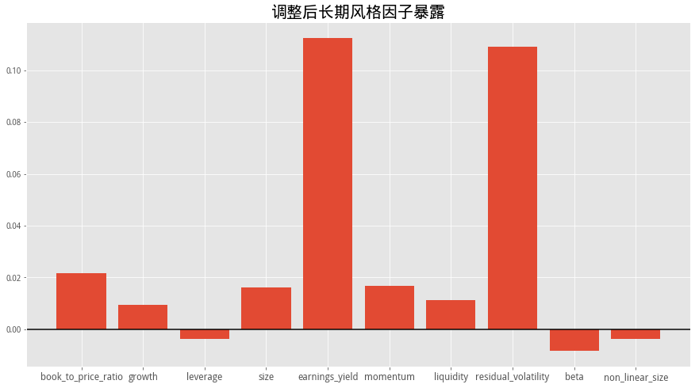

```python
import matplotlib
import matplotlib.pyplot as plt
matplotlib.style.use('ggplot')
%matplotlib inline

index = np.arange(10)
df1 = pd.Series(b)
plt.figure(figsize = (15,8))
p1 = plt.bar(index, df1)
plt.axhline(0,color = 'k')
plt.xticks(index,factor, size = 12)
plt.title('调整后长期风格因子暴露',size = 20)
plt.savefig('factor_bar.png')
```

我们发现，虚拟股票组合的持仓相对于全体A 股，在波动率、BP和Earnings Yield等风格上有较高的暴露水平，这表明全体股票型基金普遍偏好配置具有较高波动率、低估值以及大市值的股票。这展现出在统计年间基金经理普遍投资风格呈风险偏好型，即偏好金融价格波动剧烈，具有高投资回报率且可以获得更高收益的股票投资组合。同时，虚拟股票组合在杠杆率、Beta、中盘等风格上为负暴露，这表明全体股票型基金普遍偏好配置低杠杆、低Beta股票，不倾向中盘股。即基金经理配置投资组合时，往往考虑公司资产负债率低，受整体市场经济波动影响小的股票。

在我们选取的这段时间里，A 股既经历过波澜壮阔的大牛市，也经历过次贷危机的恐慌。平均值也许不能反映股市不同时期下基金经理们的投资风格偏好变化，因此我们统计了虚拟股票组合在各个时期的投资风格变化。通过移动平均与去极值处理，作时序图如下：

```python
#去极值
def delextremum(array):
    sigma = array.std()
    mu = array.mean()
    array[array > mu + 3*sigma] = mu + 3*sigma
    array[array < mu - 3*sigma] = mu - 3*sigma
    array[array >0.2] = 0
    array[array < -0.2] = 0
    return array
```

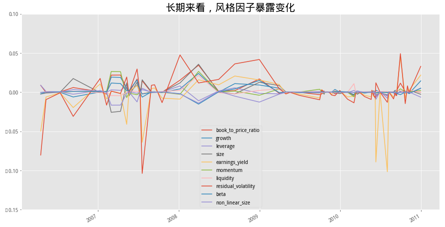

```python
#plot timeSeries factor plot
time_df = pd.DataFrame(temp_time_dict)
time_df.index = factorList
time_df.columns = pd.to_datetime(time_df.columns.astype(str), format='%Y%m%d.0')

###prepare to draw timeserise plot
btpr = delextremum(time_df.loc['book_to_price_ratio'].values).tolist()
growth = delextremum(time_df.loc['growth'].values).tolist()
leverage = delextremum(time_df.loc['leverage'].values).tolist()
size = delextremum(time_df.loc['size'].values).tolist()
ey = delextremum(time_df.loc['earnings_yield'].values).tolist()
momentum = delextremum(time_df.loc['momentum'].values).tolist()
liquidity = delextremum(time_df.loc['liquidity'].values).tolist()
rv = delextremum(time_df.loc['residual_volatility'].values).tolist()
beta = delextremum(time_df.loc['beta'].values).tolist()
nls = delextremum(time_df.loc['non_linear_size'].values).tolist()
data = {
    'book_to_price_ratio':btpr,
    'growth': growth,
    'leverage':leverage,
    'size': size,
    'earnings_yield':ey,
    'momentum':momentum,
    'liquidity':liquidity,
    'residual_volatility':rv,
    'beta':beta,
    'non_linear_size':nls
       }
data_f = pd.DataFrame(data,index=time_df.columns)
plt.figure(figsize = (15,8))
#移动平均降噪
data_f.rolling(2).mean().plot(figsize = (15,8))
plt.ylim(-0.15,0.1)
plt.title('长期来看，风格因子暴露变化',size = 20)
plt.savefig('factor_time.png')
```

我们发现，在2005至2009年间，股票型基金偏好具有动量效应，低Beta股票的风格持续存在，波动性与盈利性风格因子暴露趋势基本同步上升，投资预期向好。以09年为界，高盈利性风格股票不再受基金经理偏好，呈显著下降趋。09年下半年至10年上半年结束各风格因子暴露进入平稳期，股票型基金在各个风格上均没有展示明显的风格偏好。高波动率股票偏好在09上半年经历断崖式下跌后在10年下半年出现暴涨趋势。10年末，成长性股票同样呈现显著上涨趋势。

### 因子相关性分析

同时我们发现，多组因子间可能存在线性相关性。并且以2009年作为时间节点，因子间相关性可能存在较大的改变。为了正确评价一个风格因子在具体时期是否有效且在什么程度上有效，我们计算因子间的IC值的相关系数做一个大致的判断。

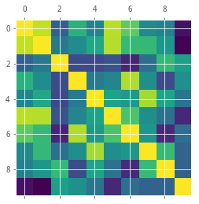

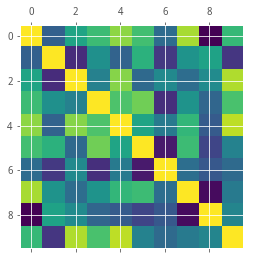

```python
data_f1 = data_f[data_f.index < "2009-01-01"]
data_f2 = data_f[data_f.index >="2009-01-01"]
plt.matshow(data_f1.corr())
plt.show()
plt.matshow(data_f2.corr())
plt.show()
```

```python
plt.figure()
data_f1.corr().style.background_gradient(cmap='coolwarm')
```

|  | book_to_price_ratio | growth | leverage | size | earnings_yield | momentum | liquidity | residual_volatility | beta | non_linear_size |
| --- | --- | --- | --- | --- | --- | --- | --- | --- | --- | --- |
| book_to_price_ratio | 1 | 0.818789 | -0.334044 | 0.299013 | -0.0634697 | 0.79655 | 0.522784 | -0.0248749 | -0.0849416 | -0.849481 |
| growth | 0.818789 | 1 | -0.154327 | 0.00817523 | 0.22142 | 0.784404 | 0.362289 | 0.351735 | 0.0825862 | -0.936828 |
| leverage | -0.334044 | -0.154327 | 1 | -0.489532 | -0.510685 | -0.437026 | -0.737608 | -0.22357 | 0.36118 | 0.159765 |
| size | 0.299013 | 0.00817523 | -0.489532 | 1 | -0.131729 | -0.0543372 | 0.766261 | 0.0255103 | -0.4918 | 0.0375579 |
| earnings_yield | -0.0634697 | 0.22142 | -0.510685 | -0.131729 | 1 | 0.187243 | 0.11242 | 0.738435 | 0.190751 | -0.189512 |
| momentum | 0.79655 | 0.784404 | -0.437026 | -0.0543372 | 0.187243 | 1 | 0.448482 | 0.0215825 | -0.208516 | -0.718711 |
| liquidity | 0.522784 | 0.362289 | -0.737608 | 0.766261 | 0.11242 | 0.448482 | 1 | 0.0800918 | -0.697561 | -0.227849 |
| residual_volatility | -0.0248749 | 0.351735 | -0.22357 | 0.0255103 | 0.738435 | 0.0215825 | 0.0800918 | 1 | 0.367347 | -0.321538 |
| beta | -0.0849416 | 0.0825862 | 0.36118 | -0.4918 | 0.190751 | -0.208516 | -0.697561 | 0.367347 | 1 | -0.322186 |
| non_linear_size | -0.849481 | -0.936828 | 0.159765 | 0.0375579 | -0.189512 | -0.718711 | -0.227849 | -0.321538 | -0.322186 | 1 |

```python
data_f2.corr().style.background_gradient(cmap='coolwarm')
```

|  | book_to_price_ratio | growth | leverage | size | earnings_yield | momentum | liquidity | residual_volatility | beta | non_linear_size |
| --- | --- | --- | --- | --- | --- | --- | --- | --- | --- | --- |
| book_to_price_ratio | 1 | -0.180106 | 0.291259 | 0.462755 | 0.714048 | 0.483899 | -0.0993137 | 0.780512 | -0.700157 | 0.436632 |
| growth | -0.180106 | 1 | -0.48179 | 0.150142 | -0.157035 | 0.393537 | -0.418562 | 0.171227 | 0.278824 | -0.430383 |
| leverage | 0.291259 | -0.48179 | 1 | 0.0452115 | 0.691366 | -0.121784 | 0.108209 | -0.0930852 | 0.122941 | 0.79979 |
| size | 0.462755 | 0.150142 | 0.0452115 | 1 | 0.527071 | 0.631221 | -0.471711 | 0.170231 | -0.141703 | 0.509226 |
| earnings_yield | 0.714048 | -0.157035 | 0.691366 | 0.527071 | 1 | 0.295158 | -0.00372728 | 0.42746 | -0.215214 | 0.827605 |
| momentum | 0.483899 | 0.393537 | -0.121784 | 0.631221 | 0.295158 | 1 | -0.575829 | 0.468156 | -0.344479 | 0.0511668 |
| liquidity | -0.0993137 | -0.418562 | 0.108209 | -0.471711 | -0.00372728 | -0.575829 | 1 | -0.0888282 | -0.234557 | -0.111554 |
| residual_volatility | 0.780512 | 0.171227 | -0.0930852 | 0.170231 | 0.42746 | 0.468156 | -0.0888282 | 1 | -0.653341 | -0.00496046 |
| beta | -0.700157 | 0.278824 | 0.122941 | -0.141703 | -0.215214 | -0.344479 | -0.234557 | -0.653341 | 1 | 0.0736956 |
| non_linear_size | 0.436632 | -0.430383 | 0.79979 | 0.509226 | 0.827605 | 0.0511668 | -0.111554 | -0.00496046 | 0.0736956 | 1 |